# L6

# Deterministic Games

- States: $S$ (starts at $s_{0}$)
- Players: $P={1{\dots}N}$ (usually take turns)
- Actions: $A$ (may depend on player / state)
- Transition function: $S$x$A$ ⟶ S
- Terminal Test: $S$ ⟶ $\{\mathrm{true}, \mathrm{false}\}$
- Terminal Utilities: $S$x$P$ ⟶ R
- Solution for a player is a policy: $S$ ⟶ $A$

## Zero-Sum Games

- Agents have opposite utilities (values on outcomes)
- Think of a single value that one maximizes and the other minimizes
- Adversarial, pure competition

### Solving Zero-Sum Games

- Have to think about how the other agent will respond to a move
- Each state has a value which is the best possible outcome at that state
  - In a tree, it is the highest value of all child states
- $\mathrm{terminality{}\implies}V(s)\;\hat{=}\;{\mathrm{known}}$
- $\mathrm{nonterminal{}\implies}V(s)=\mathrm{max}(V(s')\,\forall\,{s'\in\mathrm{successors}}(s))$
  - The opponent tries to minimize $V(s)$ instead of maximize it

#### Adversarial Search (Minimax)

- Minimax value ≔ the best achievable utility against a rational (optimal) adversary

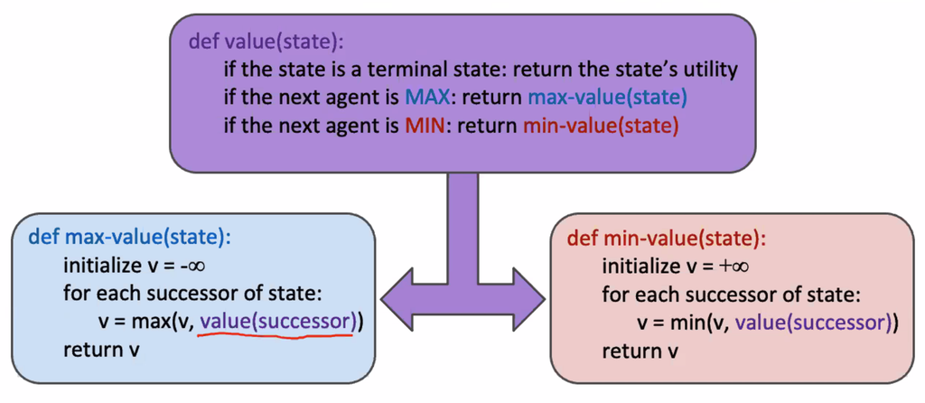

- Screenshot_2023-09-12_at_5.42.27_PM.png

- Optimal against a perfect player but not imperfect players
- $b\coloneqq\text{branching factor}$
- $m\coloneqq\text{maximum depth of game}$
- Time ∈ $O(b^{m})$
- Space ∈ $O(bm)$

##### Alpha-Beta Pruning

- Used to minimize excess calculation
- Once you have a possible value for a parent node, only evaluate children if their value **could** be propagated with optimality
- Keep track of α in maximizer nodes; if the value ≤ α for a node, ignore node and children
- Keep track of β in minimizer nodes; if the value ≥ β for a node, ignore the node and children

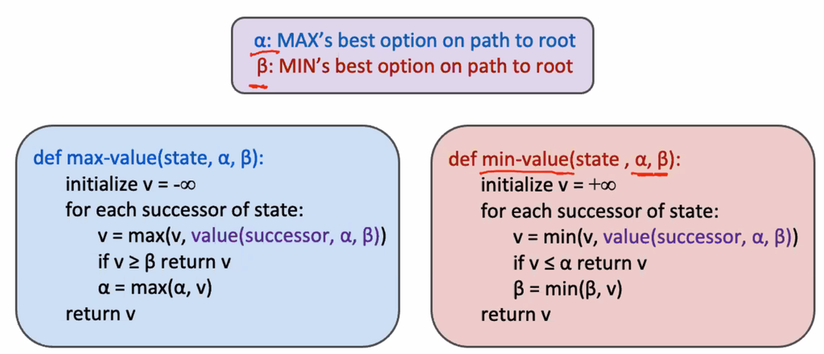

- Screenshot_2023-09-12_at_6.02.01_PM.png

- Has no effect on the minmax value computed for the root
- Values of intermediate nodes might be wrong
- Good child ordering improved effectiveness of pruning
- Time with perfect ordering ∈ $O(b^{m/2})$
  - Doubles solvable depth for a given computational power
- Simple example of metareasoning (computing about what to compute)

##### Depth-limited Search

- Search only to a limited depth in the tree
- Replace terminal utilities with an evaluation function for non-terminal positions
- Can get in an infinite loop if evaluation function is not specific enough
  - Usually a weighted linear sum of features

## General Games

- Agents have independent utilities (values on outcomes)
- Cooperation, indifference, competition, and more are all possible